# Data Analysis

## DEVELOPMENT AND DEPLOYMENT OF A STROKE RISK PREDICTION MODEL USING FLASK ON HEROKU CLOUD PLATFORM

### ABSTRACT

*To facilitate accessibility and scalability, the Flask application was deployed on the Heroku cloud platform, enabling users to access the stroke risk prediction service from anywhere via a web interface. The deployed application was thoroughly tested for functionality, performance, and user experience.*

*[The deployed stroke risk prediction model](https://stroke-risk-prediction-0697b8e1132a.herokuapp.com/) offers a user-friendly and accessible solution for individuals to assess their stroke risk conveniently. By promoting awareness and enabling early detection, this project contributes to the prevention and management of stroke-related complications, ultimately improving public health outcome.*

### INTRODUCTION

Since the 1920s, stroke has emerged as one of the foremost contributors to mortality in the United States, indiscriminately affecting individuals across all demographics (Sherwood, 2014; White, 2017). This debilitating disease transcends age, gender, socioeconomic status, and political standing, as evidenced by the deaths of prominent world leaders like former US President Franklin Delano Roosevelt, former British Prime Minister Margaret Thatcher, and former Israeli Prime Minister Ariel Sharon, all due to stroke complications (Thatcher, 2011; Weisman, 2014; White, 2017). In the United States alone, an estimated 800,000 people experience a stroke annually, placing a significant burden on the healthcare system and society. Moreover, the global impact of stroke extends beyond individual health, as its economic repercussions are substantial.

According to the Centres for Disease Control and Prevention (2023) a stroke is a grave health crisis that arises from an obstruction in blood circulation to the brain. This can be caused by a clot blocking an artery (ischemic stroke) or a blood vessel bursting (haemorrhagic stroke). The lack of blood flow damages brain tissue, which can lead to problems like weakness, numbness, or speech difficulties, and can progress to devastating problems (Katan and Luft, 2018). According to Bustamante et al., (2021), stroke can be defined as an acute cerebrovascular condition characterized by a sudden disruption of the passage of blood to the brain, resulting in focal neurological dysfunction and potential cell death due to oxygen deprivation. Dritsas and Trigka (2022) believe that the consequences of stroke can vary from short-term issues to life-altering complications, and exhibiting symptoms such as paralysis of the arms or legs, trouble speaking, trouble walking, headaches, dizziness, reduced vision, vomiting, and sensation of numbness in the face, arms, or legs.

The history of stroke could be traced as far back as 460 to 370 BC when it was called apoplexy, a Greek word meaning struck down with violence. Scholars at this time believed that the symptoms of stroke were convulsion and paralysis. And in 1658, Johann Wepfer's studies identified that stroke was caused by bleeding into the brain (haemorrhagic stroke), and the obstruction of the arteries supplying blood to the brain (ischemic stroke). Thus stroke became known as cerebrovascular disease (Ashrafan, 2010; Thompson, 1996).

In 1948, pained by the death of Franklin Roosevelt, the United States Public Health Service floated the Framingham Heart Study. The study further identified major causal risk factors for stroke. It emphasized the importance of shifting focus from merely treating diseases as they arise to preventing them and tackling factors that can be modified to reduce risks. The Framingham Study identified two key contributors to stroke risk: modifiable and non-modifiable factors, (Nilsen, 2010). Modifiable risk factors are lifestyle choices and health conditions that you can influence, such as smoking, high blood pressure, obesity, high cholesterol, and physical inactivity. By managing these factors, it is possible to considerably reduce the probability of having a stroke. The factors that cannot be modified (non-modifiable) are factors like age, genetics, or family history of stroke (Nilsen, 2010).

Early efforts at core stroke risk analysis relied on traditional statistical models. Among these models were, the Framingham Stroke Risk Profile, the COX Regression model, the QRisk Model, the CHADS(2) Stroke Risk Model, and the Reynolds Risk Score Model. Statistical models have been criticized for their inability to capture complex, non-linear interactions between various risk factors and stroke risk (Kleinbaum and Klein, 2012).

The developments in medical research came with the use of information technology systems like artificial intelligence, machine learning, and cloud computing. Logistic regression (LR), K- Nearest Neighbours (KNN), support vector machine, eXtreme Gradient Boosting (XGB), random forest, multilayer perceptron (MLP), and neural networks are now increasingly being adopted for early stroke risk prediction and the prognosis of any medical condition.

However, current studies in stroke risk prediction, lack key elements for evaluating the practical application of stroke risk prediction models. Notably, none of them reported using decision-analytic measures to assess the models' clinical utility in real-world settings to aid clinicians in making treatment decisions and estimating prognoses or assisting patients in stroke risk monitoring and prevention. So far, the models developed have a very limited reach, with little benefit or no benefit to developing countries. This rsearch work focuses on developing and deploying a web application for stroke risk prediction on a cloud platform. By leveraging the cloud's reach, this web app empowers individuals everywhere, regardless of location, education, or financial background, to assess their stroke risk with ease. Users can securely input their biomedical and lifestyle data to receive real-time, personalized, and accurate risk predictions. Furthermore, the app allows users to monitor their risk over time. They can revisit the app to reassess their risk if they experience changes in their risk factors. This web application has the potential to become a valuable companion for individuals identified as high-risk for stroke, providing ongoing support, and encouraging proactive health management that assists clinicians in making treatment decisions and estimating prognoses.

This research will adopt a multi-modal approach to stroke risk prediction, analysing and correlating different biomedical and socio-economic risk factors with stroke. I shall employ different algorithm machine learning algorithms to build, test, and evaluate my models. The algorithm with the highest accuracy predictive capability will then be fit into a Python web application framework, Flask.

Web application development is the process of creating software applications that can be used on websites. This process requires developing a front-end interphase and back-end structure. The front end of the web application will be created with HTML and CSS and the back end will be created with Python, using Flask as a framework. Flask is a Python web framework that allows machine-learning developers to create scalable, user-friendly, and flexible machine-learning web applications. To make the model widely impactful, I shall deploy it on Heroku cloud platform where anyone irrespective of geographical local, or educational level can have access to it.

### THE AIM AND OBJECTIVES

This research aims to develop a predictive model for evaluating stroke risk and deploy it on the Heroku cloud platform using Flask, a microweb framework written in Python. The following are the specific objectives.

1. Conduct a comprehensive review of existing literature on stroke risk factors, prediction models, machine learning techniques, web development framework, and cloud deployment strategies.
2. Identify and acquire suitable datasets containing relevant stroke risk factors and outcomes.
3. To evaluate and compare the performance of logistic regression, support vector machines, random forests, k-nearest neighbours, artificial neural networks, and extreme gradient boosting algorithms using appropriate metrics, such as accuracy score, F1 score, precision, recall, and area under the curve.
4. To integrate the best-performing model into the Flask application and design a user-friendly web interface that allows users to input their health information and receive personalized stroke risk predictions.
5. To configure and deploy the Flask application on the Heroku cloud platform, considering security, scalability, and accessibility.

### RESEARCH QUESTIONS

This study investigates the following research questions:

1. What are the current trends and advancements in stroke risk factor identification, prediction models, machine learning techniques, web development frameworks, and cloud deployment strategies?
2. What are the most suitable publicly available datasets that contain relevant stroke risk factors and outcomes, and that fulfil the ethical and privacy requirements of this dissertation?
3. What machine learning algorithms demonstrate the highest performance in predicting stroke risk when evaluated against metrics such as accuracy, precision, recall, and AUC?
4. How can the developed stroke prediction model be effectively integrated into a Flask application to provide personalized risk predictions for users?
5. How can the developed prediction model be seamlessly integrated into the Flask application, while ensuring real-time predictions and user-friendly interaction?

### Conceptual Framework

[figure not shown]

### RESEARCH LIMITATIONS

This dissertation utilized a publicly available dataset for stroke risk prediction model development. While this approach facilitated efficient exploration of machine learning techniques, it also limited the study's ability to address specific characteristics of a targeted population. However, it is important to acknowledge the significant resource requirements associated with primary data collection. Such endeavours can be time-consuming due to data-gathering processes. Additionally, funding limitations and ethical considerations surrounding patient privacy can pose significant challenges.

Another limitation to consider is the class imbalance within the dataset. The output variable exhibited a bias towards individuals without stroke. While this imbalance was addressed through SMOTE (Synthetic Minority Oversampling Technique) normalization, it's worth acknowledging this potential limitation for future research endeavours.

The ongoing cost of cloud deployment presents a potential limitation for long-term model operation. Exploring alternative deployment strategies, such as on-premises infrastructure or cost-optimized cloud services, could be a future consideration.

## DATA ANALYTICS AND MODEL DEPLOYMENT

### Deployment Procedure

[figure not shown]

### Data Source

This dissertation utilized a secondary dataset of electronic health records of patients released by McKinsey and Company and available from a certified open-source repository. This dataset contains 5110 records of patients. The dataset was in its raw, uncleaned state and contained 11 input variables and 1 output variable. The output variable was in a binary state, where 1 represents patients who have suffered a stroke, and 0 represents patients who have not. The output variable had highly imbalanced classes where 95% of the patients never had a stroke and only 5% have had a stroke. The study employed a profoundly professional statistical method to handle this imbalance. The 11 input variables in my dataset are Patient ID (this was dropped, as it is not useful to the study), gender, age, hypertension, heart disease, marital status, occupation, residence type, average glucose level, body mass index, and smoking status. The dataset publisher adheres to industry best practices for ethical data collection, such as informed consent and data anonymization, thus this data research is highly suitable for my dissertation.

[Link to dataset](https://www.kaggle.com/datasets/fedesoriano/stroke-prediction-dataset)

### Data Loading and Inspection

#### Import Libraries

```python
import matplotlib.pyplot as plt   #Used for creating visualizations.
%matplotlib inline
import pandas as pd                #Used for data manipulation and analysis
import numpy as np                 #Used for numerical computations and array operations.
import seaborn as sns         #Built on top of matplotlib, offering a higher-level interface for creating statistical graphics.
```

```python
stroke_df = pd.read_csv(r"C:\Users\User\OneDrive - Cardiff Metropolitan University\Dissertation\Data Analytics\healthcare-dataset-stroke-data.csv")
```

```python
stroke_df
```

|  | id | gender | age | hypertension | heart_disease | ever_married | work_type | Residence_type | avg_glucose_level | bmi | smoking_status | stroke |
| --- | --- | --- | --- | --- | --- | --- | --- | --- | --- | --- | --- | --- |
| 0 | 9046 | Male | 67.0 | 0 | 1 | Yes | Private | Urban | 228.69 | 36.6 | formerly smoked | 1 |
| 1 | 51676 | Female | 61.0 | 0 | 0 | Yes | Self-employed | Rural | 202.21 | NaN | never smoked | 1 |
| 2 | 31112 | Male | 80.0 | 0 | 1 | Yes | Private | Rural | 105.92 | 32.5 | never smoked | 1 |
| 3 | 60182 | Female | 49.0 | 0 | 0 | Yes | Private | Urban | 171.23 | 34.4 | smokes | 1 |
| 4 | 1665 | Female | 79.0 | 1 | 0 | Yes | Self-employed | Rural | 174.12 | 24.0 | never smoked | 1 |
| ... | ... | ... | ... | ... | ... | ... | ... | ... | ... | ... | ... | ... |
| 5105 | 18234 | Female | 80.0 | 1 | 0 | Yes | Private | Urban | 83.75 | NaN | never smoked | 0 |
| 5106 | 44873 | Female | 81.0 | 0 | 0 | Yes | Self-employed | Urban | 125.20 | 40.0 | never smoked | 0 |
| 5107 | 19723 | Female | 35.0 | 0 | 0 | Yes | Self-employed | Rural | 82.99 | 30.6 | never smoked | 0 |
| 5108 | 37544 | Male | 51.0 | 0 | 0 | Yes | Private | Rural | 166.29 | 25.6 | formerly smoked | 0 |
| 5109 | 44679 | Female | 44.0 | 0 | 0 | Yes | Govt_job | Urban | 85.28 | 26.2 | Unknown | 0 |

5110 rows × 12 columns

```python
sns.set_style("whitegrid")
plt.style.use("fivethirtyeight")
```

```python
stroke_df.head() #inspect five five columns of the dataset
```

|  | id | gender | age | hypertension | heart_disease | ever_married | work_type | Residence_type | avg_glucose_level | bmi | smoking_status | stroke |
| --- | --- | --- | --- | --- | --- | --- | --- | --- | --- | --- | --- | --- |
| 0 | 9046 | Male | 67.0 | 0 | 1 | Yes | Private | Urban | 228.69 | 36.6 | formerly smoked | 1 |
| 1 | 51676 | Female | 61.0 | 0 | 0 | Yes | Self-employed | Rural | 202.21 | NaN | never smoked | 1 |
| 2 | 31112 | Male | 80.0 | 0 | 1 | Yes | Private | Rural | 105.92 | 32.5 | never smoked | 1 |
| 3 | 60182 | Female | 49.0 | 0 | 0 | Yes | Private | Urban | 171.23 | 34.4 | smokes | 1 |
| 4 | 1665 | Female | 79.0 | 1 | 0 | Yes | Self-employed | Rural | 174.12 | 24.0 | never smoked | 1 |

```python
stroke_df.info()
```

```
<class 'pandas.core.frame.DataFrame'>
RangeIndex: 5110 entries, 0 to 5109
Data columns (total 12 columns):
 #   Column             Non-Null Count  Dtype
---  ------             --------------  -----
 0   id                 5110 non-null   int64
 1   gender             5110 non-null   object
 2   age                5110 non-null   float64
 3   hypertension       5110 non-null   int64
 4   heart_disease      5110 non-null   int64
 5   ever_married       5110 non-null   object
 6   work_type          5110 non-null   object
 7   Residence_type     5110 non-null   object
 8   avg_glucose_level  5110 non-null   float64
 9   bmi                4909 non-null   float64
 10  smoking_status     5110 non-null   object
 11  stroke             5110 non-null   int64
dtypes: float64(3), int64(4), object(5)
memory usage: 479.2+ KB
```

```python
stroke_df.isna().sum()
```

```
id                     0
gender                 0
age                    0
hypertension           0
heart_disease          0
ever_married           0
work_type              0
Residence_type         0
avg_glucose_level      0
bmi                  201
smoking_status         0
stroke                 0
dtype: int64
```

```python
stroke_df.describe()
```

|  | id | age | hypertension | heart_disease | avg_glucose_level | bmi | stroke |
| --- | --- | --- | --- | --- | --- | --- | --- |
| count | 5110.000000 | 5110.000000 | 5110.000000 | 5110.000000 | 5110.000000 | 4909.000000 | 5110.000000 |
| mean | 36517.829354 | 43.226614 | 0.097456 | 0.054012 | 106.147677 | 28.893237 | 0.048728 |
| std | 21161.721625 | 22.612647 | 0.296607 | 0.226063 | 45.283560 | 7.854067 | 0.215320 |
| min | 67.000000 | 0.080000 | 0.000000 | 0.000000 | 55.120000 | 10.300000 | 0.000000 |
| 25% | 17741.250000 | 25.000000 | 0.000000 | 0.000000 | 77.245000 | 23.500000 | 0.000000 |
| 50% | 36932.000000 | 45.000000 | 0.000000 | 0.000000 | 91.885000 | 28.100000 | 0.000000 |
| 75% | 54682.000000 | 61.000000 | 0.000000 | 0.000000 | 114.090000 | 33.100000 | 0.000000 |
| max | 72940.000000 | 82.000000 | 1.000000 | 1.000000 | 271.740000 | 97.600000 | 1.000000 |

## Data Cleaning

```python
stroke_df.duplicated()
```

[output not shown]

**LETS FILL NULL VALUES**

Our Body Mass Index (BMI) column has 201 null values. It will be wrong to fill null values with average body mass index because BMI could vary with different factors like sex or age. I will use the box-plot to confirm if there is a significant difference in BMI with sex

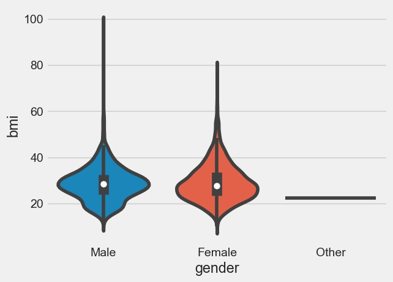

```python
sns.violinplot(x='gender',y='bmi', data = stroke_df)
```

```python
stroke_df['AgeLabel'] = pd.cut(x=stroke_df['age'], bins=[0, 3, 17, 63, 99],
                     labels=['Toddler', 'Child','Adult','Elderly'])
```

```python
stroke_df
```

|  | id | gender | age | hypertension | heart_disease | ever_married | work_type | Residence_type | avg_glucose_level | bmi | smoking_status | stroke | AgeLabel |
| --- | --- | --- | --- | --- | --- | --- | --- | --- | --- | --- | --- | --- | --- |
| 0 | 9046 | Male | 67.0 | 0 | 1 | Yes | Private | Urban | 228.69 | 36.6 | formerly smoked | 1 | Elderly |
| 1 | 51676 | Female | 61.0 | 0 | 0 | Yes | Self-employed | Rural | 202.21 | NaN | never smoked | 1 | Adult |
| 2 | 31112 | Male | 80.0 | 0 | 1 | Yes | Private | Rural | 105.92 | 32.5 | never smoked | 1 | Elderly |
| 3 | 60182 | Female | 49.0 | 0 | 0 | Yes | Private | Urban | 171.23 | 34.4 | smokes | 1 | Adult |
| 4 | 1665 | Female | 79.0 | 1 | 0 | Yes | Self-employed | Rural | 174.12 | 24.0 | never smoked | 1 | Elderly |
| ... | ... | ... | ... | ... | ... | ... | ... | ... | ... | ... | ... | ... | ... |
| 5105 | 18234 | Female | 80.0 | 1 | 0 | Yes | Private | Urban | 83.75 | NaN | never smoked | 0 | Elderly |
| 5106 | 44873 | Female | 81.0 | 0 | 0 | Yes | Self-employed | Urban | 125.20 | 40.0 | never smoked | 0 | Elderly |
| 5107 | 19723 | Female | 35.0 | 0 | 0 | Yes | Self-employed | Rural | 82.99 | 30.6 | never smoked | 0 | Adult |
| 5108 | 37544 | Male | 51.0 | 0 | 0 | Yes | Private | Rural | 166.29 | 25.6 | formerly smoked | 0 | Adult |
| 5109 | 44679 | Female | 44.0 | 0 | 0 | Yes | Govt_job | Urban | 85.28 | 26.2 | Unknown | 0 | Adult |

5110 rows × 13 columns

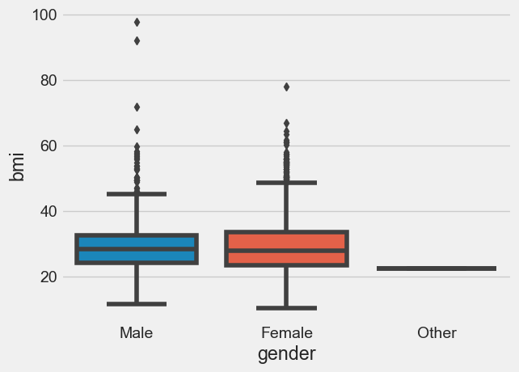

```python
# plt.figure(figsize=(10,4))
sns.boxplot(x='gender',y='bmi', data = stroke_df)
plt.show()
```

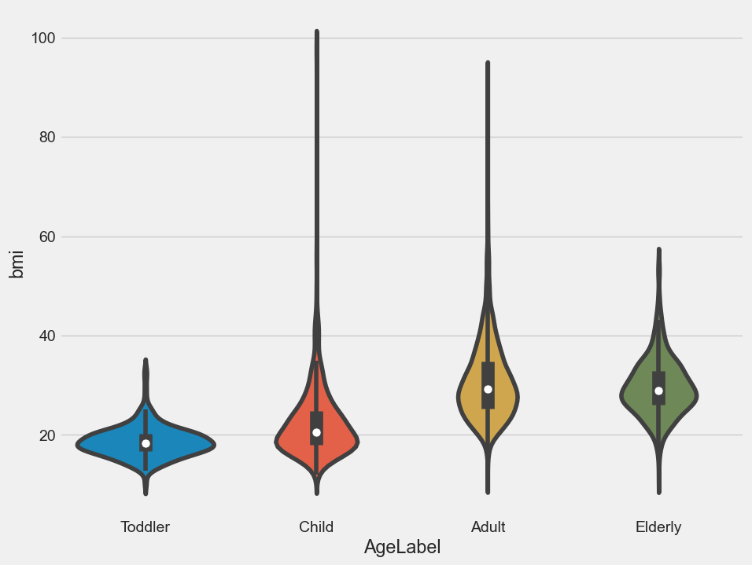

```python
plt.figure(figsize=(10,8))
sns.violinplot(x='AgeLabel',y='bmi', data = stroke_df)
```

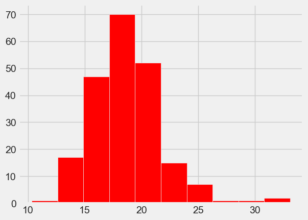

```python
plt.hist(stroke_df[stroke_df['AgeLabel']=='Toddler']['bmi'], color='red')
plt.show()
```

```python
stroke_df[stroke_df['AgeLabel']=='Toddler']['bmi'].describe()
```

```
count    213.000000
mean      18.664789
std        3.096884
min       10.300000
25%       16.800000
50%       18.300000
75%       20.300000
max       33.100000
Name: bmi, dtype: float64
```

**The mean BMI of the Toddler category is 19 appriximately**

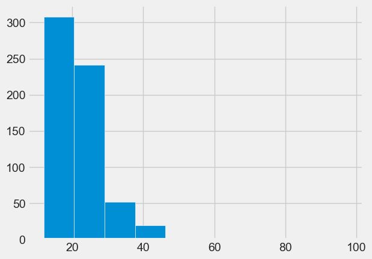

```python
plt.hist(stroke_df[stroke_df['AgeLabel']=='Child']['bmi'])
plt.show()
```

```python
stroke_df[stroke_df['AgeLabel']=='Child']['bmi'].describe()
```

```
count    623.000000
mean      22.325361
std        6.799040
min       12.000000
25%       18.000000
50%       20.600000
75%       24.800000
max       97.600000
Name: bmi, dtype: float64
```

#### The mean BMI of the Child category is 22 appriximately

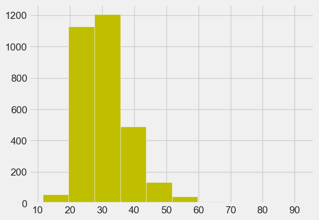

```python
plt.hist(stroke_df[stroke_df['AgeLabel']=='Adult']['bmi'], color='y')
plt.show()
```

```python
stroke_df[stroke_df['AgeLabel']=='Adult']['bmi'].describe()
```

```
count    3068.000000
mean       30.699772
std         7.638310
min        11.500000
25%        25.275000
50%        29.300000
75%        34.700000
max        92.000000
Name: bmi, dtype: float64
```

#### The mean BMI of the adult category is 31 appriximately

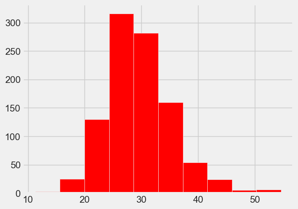

```python
plt.hist(stroke_df[stroke_df['AgeLabel']=='Elderly']['bmi'], color='r')
plt.show()
```

```python
stroke_df[stroke_df['AgeLabel']=='Elderly']['bmi'].describe()
```

```
count    1005.000000
mean       29.617612
std         5.761813
min        11.300000
25%        26.000000
50%        28.900000
75%        32.900000
max        54.600000
Name: bmi, dtype: float64
```

The mean BMI of the Elderly category is 30 appriximately

We shall create a function that will replace the null values in the BMI column with the mean BMI for each age category

```python
#lets create a function

def fill_bmi(col):
    bmi = col[0]
    AgeLabel = col[1]

    # We checking if there is a null value in bmi column
    if pd.isnull(bmi):

        # sampled toddlers class
        if AgeLabel == 'Toddler':
            return 19
        #respondents in child age group
        elif AgeLabel == 'Child':
            return 22
        elif AgeLabel == 'Adult':
            return 31
        #For passengers in 3rd class
        else:
            return 30

    else:
        # if no null values, just retun our known bmi value
        return bmi
```

**We shall fill the BMI column with the average mean bmi per age category**

```python
stroke_df['bmi'] = stroke_df[['bmi','AgeLabel']].apply(fill_bmi,axis=1)
```

```python
stroke_df.isna().sum()
```

```
id                   0
gender               0
age                  0
hypertension         0
heart_disease        0
ever_married         0
work_type            0
Residence_type       0
avg_glucose_level    0
bmi                  0
smoking_status       0
stroke               0
AgeLabel             0
dtype: int64
```

## Exploratory Data Analysis

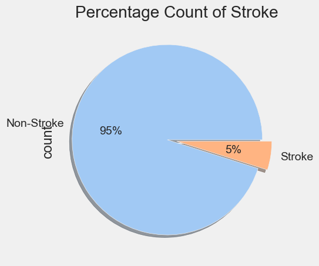

```python
fig,ax=plt.subplots(figsize = (5,5))
lab = ['Non-Stroke','Stroke']
col = sns.color_palette('pastel')[0:5]
stroke_df['stroke'].value_counts().plot.pie(explode=[0.1,0.0],autopct='%1.f%%',shadow=True,labels = lab, colors = col)
plt.title("Percentage Count of Stroke")
plt.show()
```

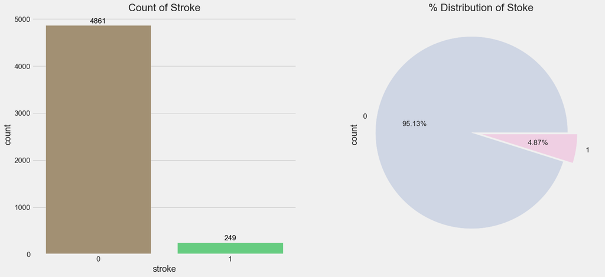

```python
plt.figure(figsize=(18,8))
plt.subplot(1,2,1)
vc = stroke_df['stroke'].value_counts()
g = sns.barplot(x=vc.index,y=vc, palette='terrain_r')
for p in g.patches:
    g.annotate('{:.0f}'.format(p.get_height()), (p.get_x()+0.4, p.get_height()+20),ha='center', va='bottom',
               color= 'black')
plt.title('Count of Stroke')
plt.subplot(1,2,2)
colors = ['#CFD6E4', '#EFCFE3', '#E4F0CF', '#F3CFB6', '#B9DCCC']
stroke_df['stroke'].value_counts().plot(kind='pie', explode=[0.1,0], autopct='%.2f%%', colors=colors)
plt.title('% Distribution of Stoke')
plt.show()
```

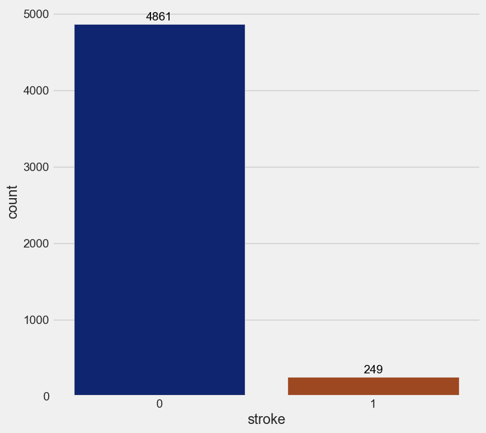

```python
plt.figure(figsize=(18,8))
plt.subplot(1,2,1)
vc = stroke_df['stroke'].value_counts()
g = sns.barplot(x=vc.index,y=vc, palette='dark')
for p in g.patches:
    g.annotate('{:.0f}'.format(p.get_height()), (p.get_x()+0.4, p.get_height()+20),ha='center', va='bottom',
               color= 'black')
```

```python
stroke_df.columns
```

```
Index(['id', 'gender', 'age', 'hypertension', 'heart_disease', 'ever_married',
       'work_type', 'Residence_type', 'avg_glucose_level', 'bmi',
       'smoking_status', 'stroke', 'AgeLabel'],
      dtype='object')
```

Drop the 'id' column it is not useful

```python
stroke_df=stroke_df.drop('id',axis=1)
```

```python
stroke_df
```

|  | gender | age | hypertension | heart_disease | ever_married | work_type | Residence_type | avg_glucose_level | bmi | smoking_status | stroke | AgeLabel |
| --- | --- | --- | --- | --- | --- | --- | --- | --- | --- | --- | --- | --- |
| 0 | Male | 67.0 | 0 | 1 | Yes | Private | Urban | 228.69 | 36.6 | formerly smoked | 1 | Elderly |
| 1 | Female | 61.0 | 0 | 0 | Yes | Self-employed | Rural | 202.21 | 31.0 | never smoked | 1 | Adult |
| 2 | Male | 80.0 | 0 | 1 | Yes | Private | Rural | 105.92 | 32.5 | never smoked | 1 | Elderly |
| 3 | Female | 49.0 | 0 | 0 | Yes | Private | Urban | 171.23 | 34.4 | smokes | 1 | Adult |
| 4 | Female | 79.0 | 1 | 0 | Yes | Self-employed | Rural | 174.12 | 24.0 | never smoked | 1 | Elderly |
| ... | ... | ... | ... | ... | ... | ... | ... | ... | ... | ... | ... | ... |
| 5105 | Female | 80.0 | 1 | 0 | Yes | Private | Urban | 83.75 | 30.0 | never smoked | 0 | Elderly |
| 5106 | Female | 81.0 | 0 | 0 | Yes | Self-employed | Urban | 125.20 | 40.0 | never smoked | 0 | Elderly |
| 5107 | Female | 35.0 | 0 | 0 | Yes | Self-employed | Rural | 82.99 | 30.6 | never smoked | 0 | Adult |
| 5108 | Male | 51.0 | 0 | 0 | Yes | Private | Rural | 166.29 | 25.6 | formerly smoked | 0 | Adult |
| 5109 | Female | 44.0 | 0 | 0 | Yes | Govt_job | Urban | 85.28 | 26.2 | Unknown | 0 | Adult |

5110 rows × 12 columns

**Visualizing countplot for gender,ever_married, work_type, Residence_type,smoking_status**

```python
stroke_df.columns
```

```
Index(['gender', 'age', 'hypertension', 'heart_disease', 'ever_married',
       'work_type', 'Residence_type', 'avg_glucose_level', 'bmi',
       'smoking_status', 'stroke', 'AgeLabel'],
      dtype='object')
```

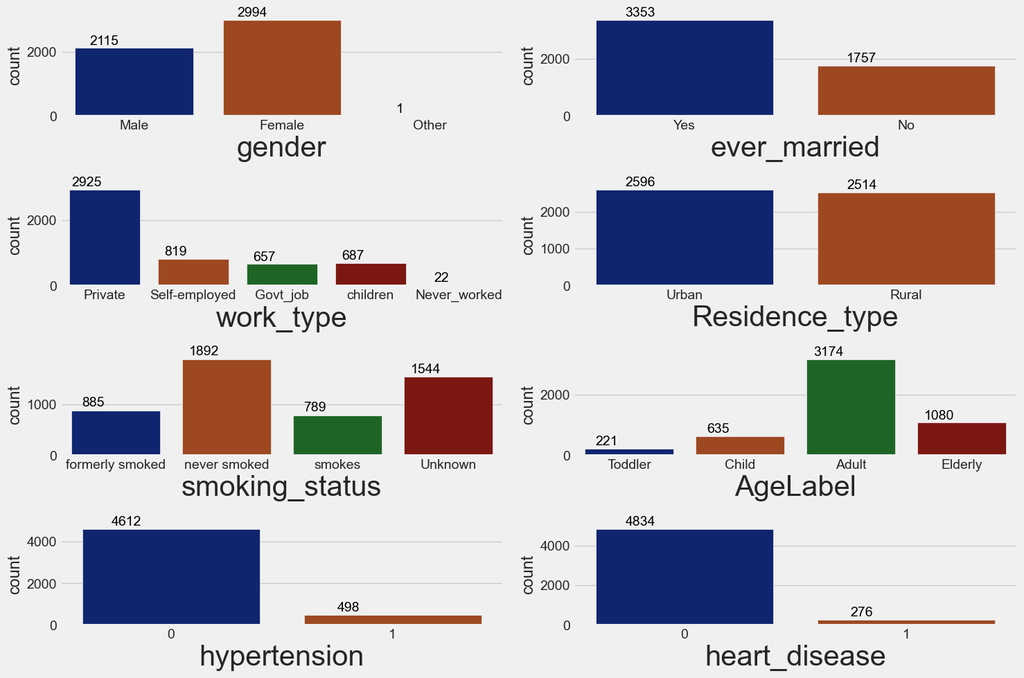

```python
plt.figure(figsize=(15,10))

col= ['gender','ever_married','work_type','Residence_type','smoking_status', 'AgeLabel','hypertension', 'heart_disease']
i = 1
for a in col:

    plt.subplot(4,2,i)
    g = sns.countplot(x=a,data=stroke_df,palette="dark")
    for p in g.patches:
        g.annotate('{:.0f}'.format(p.get_height()), (p.get_x()+0.2, p.get_height()+20),ha='center', va='bottom',
                   color= 'black')
        plt.xlabel(a,fontsize=30)
    i = i+1

plt.tight_layout()
```

**Convert features into categorical and continuous variables based on data type to aid understanding of EDA**

```python
categorical_val = []
continous_val = []
for column in stroke_df.columns:
    #here we are using a threshold to check the categories in the
    #columns
    if len(stroke_df[column].unique()) <= 10:
        categorical_val.append(column)
    else:
        continous_val.append(column)
print(continous_val)
```

```
['age', 'avg_glucose_level', 'bmi']
```

**Visualize count plot for continous variables**

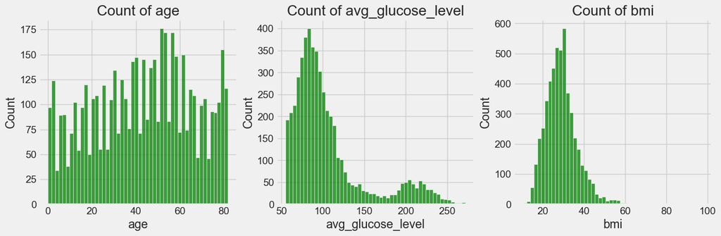

```python
plt.figure(figsize=(15,15))
for i, column in enumerate(continous_val):
  plt.subplot(3, 3, i+1)
  sns.histplot(x=column, bins=50, data= stroke_df, color='g')
  plt.title('Count of '+ column)
plt.show()
```

**Visualizing countplot for stroke by categorical values**

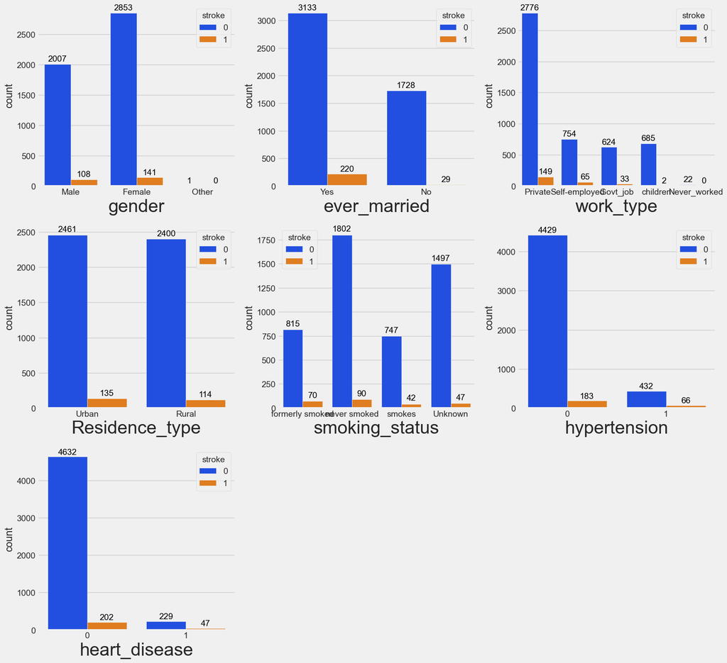

```python
plt.figure(figsize=(17,20))

col= ['gender','ever_married','work_type','Residence_type','smoking_status', 'hypertension','heart_disease']
i = 1
for a in col:

    plt.subplot(4,3,i)
    g = sns.countplot(x=a,hue='stroke',data=stroke_df,palette='bright')
    for p in g.patches:
        g.annotate('{:.0f}'.format(p.get_height()), (p.get_x()+0.2, p.get_height()+20),ha='center', va='bottom',
                   color= 'black')
        plt.xlabel(a,fontsize=30)

    i = i+1

plt.tight_layout()
```

**Visualizing countplot for stroke by continous values**

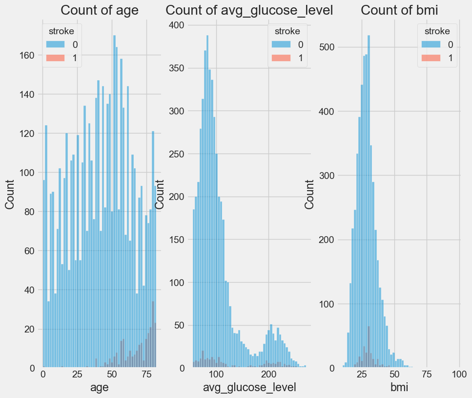

```python
plt.figure(figsize=(10,30))
for i, column in enumerate(continous_val):
  plt.subplot(3, 3, i+1)
  sns.histplot(x=column, bins=50, hue='stroke', data= stroke_df, color='red')
  plt.title('Count of '+ column)
    #plt.show()
```

## Discussion

This research leverages the visualization libraries Seaborn and Matplotlib to effectively explore the distribution of its variables. By employing histograms, count plots, and pie charts within a subplot layout, the analysis presents a comprehensive overview, enabling readers to grasp key insights immediately. This approach minimizes the need for scrolling through individual plots, promoting efficient data exploration and interpretation.

My dataset presents an array of different features with variations in distribution. This is expected when a random sampling technique is employed.

# Preprocessing

**Label Encoder**

```python
from sklearn.preprocessing import LabelEncoder
le=LabelEncoder()
```

```python
stroke_df['ever_married']= le.fit_transform(stroke_df['ever_married'])
stroke_df['gender']= le.fit_transform(stroke_df['gender'])
stroke_df['work_type']= le.fit_transform(stroke_df['work_type'])
stroke_df['Residence_type']= le.fit_transform(stroke_df['Residence_type'])
stroke_df['smoking_status']= le.fit_transform(stroke_df['smoking_status'])
```

```python
stroke_df
```

|  | gender | age | hypertension | heart_disease | ever_married | work_type | Residence_type | avg_glucose_level | bmi | smoking_status | stroke | AgeLabel |
| --- | --- | --- | --- | --- | --- | --- | --- | --- | --- | --- | --- | --- |
| 0 | 1 | 67.0 | 0 | 1 | 1 | 2 | 1 | 228.69 | 36.6 | 1 | 1 | Elderly |
| 1 | 0 | 61.0 | 0 | 0 | 1 | 3 | 0 | 202.21 | 31.0 | 2 | 1 | Adult |
| 2 | 1 | 80.0 | 0 | 1 | 1 | 2 | 0 | 105.92 | 32.5 | 2 | 1 | Elderly |
| 3 | 0 | 49.0 | 0 | 0 | 1 | 2 | 1 | 171.23 | 34.4 | 3 | 1 | Adult |
| 4 | 0 | 79.0 | 1 | 0 | 1 | 3 | 0 | 174.12 | 24.0 | 2 | 1 | Elderly |
| ... | ... | ... | ... | ... | ... | ... | ... | ... | ... | ... | ... | ... |
| 5105 | 0 | 80.0 | 1 | 0 | 1 | 2 | 1 | 83.75 | 30.0 | 2 | 0 | Elderly |
| 5106 | 0 | 81.0 | 0 | 0 | 1 | 3 | 1 | 125.20 | 40.0 | 2 | 0 | Elderly |
| 5107 | 0 | 35.0 | 0 | 0 | 1 | 3 | 0 | 82.99 | 30.6 | 2 | 0 | Adult |
| 5108 | 1 | 51.0 | 0 | 0 | 1 | 2 | 0 | 166.29 | 25.6 | 1 | 0 | Adult |
| 5109 | 0 | 44.0 | 0 | 0 | 1 | 0 | 1 | 85.28 | 26.2 | 0 | 0 | Adult |

5110 rows × 12 columns

Drop the AgeLabel column

```python
stroke_df.drop('AgeLabel',axis=1, inplace=True)
```

```python
stroke_df
```

|  | gender | age | hypertension | heart_disease | ever_married | work_type | Residence_type | avg_glucose_level | bmi | smoking_status | stroke |
| --- | --- | --- | --- | --- | --- | --- | --- | --- | --- | --- | --- |
| 0 | 1 | 67.0 | 0 | 1 | 1 | 2 | 1 | 228.69 | 36.6 | 1 | 1 |
| 1 | 0 | 61.0 | 0 | 0 | 1 | 3 | 0 | 202.21 | 31.0 | 2 | 1 |
| 2 | 1 | 80.0 | 0 | 1 | 1 | 2 | 0 | 105.92 | 32.5 | 2 | 1 |
| 3 | 0 | 49.0 | 0 | 0 | 1 | 2 | 1 | 171.23 | 34.4 | 3 | 1 |
| 4 | 0 | 79.0 | 1 | 0 | 1 | 3 | 0 | 174.12 | 24.0 | 2 | 1 |
| ... | ... | ... | ... | ... | ... | ... | ... | ... | ... | ... | ... |
| 5105 | 0 | 80.0 | 1 | 0 | 1 | 2 | 1 | 83.75 | 30.0 | 2 | 0 |
| 5106 | 0 | 81.0 | 0 | 0 | 1 | 3 | 1 | 125.20 | 40.0 | 2 | 0 |
| 5107 | 0 | 35.0 | 0 | 0 | 1 | 3 | 0 | 82.99 | 30.6 | 2 | 0 |
| 5108 | 1 | 51.0 | 0 | 0 | 1 | 2 | 0 | 166.29 | 25.6 | 1 | 0 |
| 5109 | 0 | 44.0 | 0 | 0 | 1 | 0 | 1 | 85.28 | 26.2 | 0 | 0 |

5110 rows × 11 columns

## Correlation Matrix

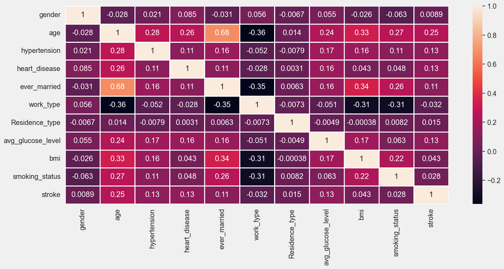

```python
plt.figure(figsize=(16,8))
sns.set_context('notebook',font_scale = 1.3)
sns.heatmap(stroke_df.corr(),annot=True,linewidth =2)
plt.tight_layout()
```

**Correlation of stroke with input variables**

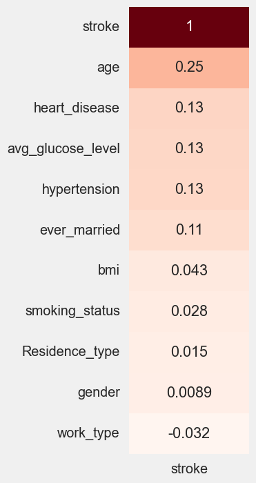

```python
stroke_corr= stroke_df.corr()['stroke'].sort_values(ascending=False).to_frame()
plt.figure(figsize=(2,8))
sns.heatmap(stroke_corr, cmap='Reds', cbar=False , annot=True)
plt.show()
```

### Discussing Correlations

To explore the strength of relationships between stroke and its attributes feature, I employed Pearson’s correlation coefficient to generate a heatmap. The correlation value will determine the strength of the linear relationship between any two features of the patient’s electronic health data. I have used a heatmap show insights such that dark red means a perfect relationship, and the shades of red fades-out as you move down the ladder to a negative relationship.

The correlation coefficient between stroke and age, heart disease, average glucose level and hypertension, and marital status is 0.25, 0.13, 0.13, 0.13, and 0.11 respectively. This makes age the most correlated feature to stroke. It shows that there is a positive correlation of stroke to these features; this implies that the higher the age, glucose level, body mass index the higher the risk of having a stroke, and the presence of heart, hypertension increases the chances of a stroke. We also see that gender has very weak relationship with stroke.

### Feature Selection

```python
X= np.asarray(stroke_df[['gender', 'age','hypertension', 'heart_disease',
                         'ever_married', 'work_type', 'Residence_type',
                         'avg_glucose_level',
                         'bmi','smoking_status']])
```

```python
y=np.asarray(stroke_df['stroke'])
y[0:5]
```

```
array([1, 1, 1, 1, 1], dtype=int64)
```

### Data Standardization

I am going to use standardScaler for data standardization

```python
from sklearn.preprocessing import StandardScaler
std=StandardScaler()
```

```python
X=std.fit_transform(X)
```

```python
X
```

```
array([[ 1.18807255,  1.05143428, -0.32860186, ...,  2.70637544,
         0.99442704, -0.35178071],
       [-0.840344  ,  0.78607007, -0.32860186, ...,  2.12155854,
         0.26918169,  0.58155233],
       [ 1.18807255,  1.62639008, -0.32860186, ..., -0.0050283 ,
         0.46344384,  0.58155233],
       ...,
       [-0.840344  , -0.36384151, -0.32860186, ..., -0.51144264,
         0.21737846,  0.58155233],
       [ 1.18807255,  0.34379639, -0.32860186, ...,  1.32825706,
        -0.43016203, -0.35178071],
       [-0.840344  ,  0.03420481, -0.32860186, ..., -0.46086746,
        -0.35245718, -1.28511375]])
```

### SPLIT DATA INTO TRAINING AND TESTING

Splitting is an act of dividing the dataset by rows into two parts, for training and testing. For better accuracy and efficiency, I am splitting the data set into 80% for training data and 20% for testing.

```python
from sklearn.model_selection import train_test_split
```

```python
X_train , X_test , y_train , y_test = train_test_split(X,y,test_size=0.2,random_state=None)
```

```python
print("Number transactions X_train dataset: ", X_train.shape)
print("Number transactions y_train dataset: ", y_train.shape)
print("Number transactions X_test dataset: ", X_test.shape)
print("Number transactions y_test dataset: ", y_test.shape)
```

```
Number transactions X_train dataset:  (4088, 10)
Number transactions y_train dataset:  (4088,)
Number transactions X_test dataset:  (1022, 10)
Number transactions y_test dataset:  (1022,)
```

### Handle Imbalance Data

This imbalance in the dataset is a situation where a class of the output variable has significantly fewer instances compared to the other class. Class imbalance is a common issue, and it can impact the performance of machine learning models (Tahir, et al. 2019).

```python
from imblearn.over_sampling import SMOTE
```

```python
print("Before OverSampling, counts of label '1': {}".format(sum(y_train==1)))
print("Before OverSampling, counts of label '0': {} \n".format(sum(y_train==0)))
```

```
Before OverSampling, counts of label '1': 195
Before OverSampling, counts of label '0': 3893
```

```python
sm = SMOTE(random_state=2)


X_train_res, y_train_res = sm.fit_resample(X_train, y_train.ravel())
```

```python
print("After OverSampling, counts of label '1': {}".format(sum(y_train_res==1)))
print("After OverSampling, counts of label '0': {}".format(sum(y_train_res==0)))
```

```
After OverSampling, counts of label '1': 3893
After OverSampling, counts of label '0': 3893
```

## Model Building

```python
#Import evaluation libraries
from sklearn.metrics import confusion_matrix, accuracy_score,classification_report,roc_auc_score,roc_curve
```

### Logistic Regression

```python
from sklearn.linear_model import LogisticRegression #import libraries
lg_model = LogisticRegression()                      #create model
lg_model.fit(X_train_res, y_train_res)               #train model
y_pred_lr = lg_model.predict(X_test)                  #test mdel
```

```python
ac_lr = lg_model.score(X_test,y_test)*100
```

```python
ac_lr
```

```
73.77690802348337
```

```python
auc_lr = roc_auc_score(y_test,y_pred_lr)*100
```

```python
auc_lr
```

```
75.66574839302112
```

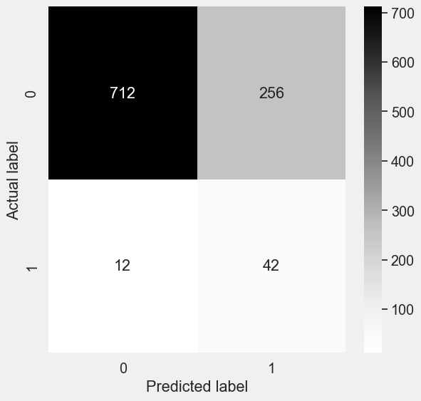

```
              precision    recall  f1-score   support

           0       0.98      0.74      0.84       968
           1       0.14      0.78      0.24        54

    accuracy                           0.74      1022
   macro avg       0.56      0.76      0.54      1022
weighted avg       0.94      0.74      0.81      1022

Logistic AUC: 0.757
Accuracy of The Model : 73.77690802348337
```

```python
plt.figure(figsize=(6, 6))
ax = plt.subplot()
cm = confusion_matrix(y_test,y_pred_lr)
sns.heatmap(cm, annot=True, ax = ax, fmt = 'g' ,cmap=plt.cm.Greys)
ax.set_xlabel('Predicted label')
ax.set_ylabel('Actual label')
plt.show()

print(classification_report(y_test,y_pred_lr))
print('Logistic AUC: {:.3f}'.format(roc_auc_score(y_test, y_pred_lr)))
print("Accuracy of The Model :",accuracy_score(y_test,y_pred_lr)*100)
```

### SUPPORT VECTOR MECHINE

```python
from sklearn.svm import SVC
svm_model = SVC()
svm_model.fit(X_train_res,y_train_res)
```

```
SVC()
```

```python
y_pred_svm = svm_model.predict(X_test)
```

```python
ac_svm = svm_model.score(X_test,y_test)*100
ac_svm
```

```
76.22309197651663
```

```python
auc_svm = roc_auc_score(y_test,y_pred_svm)*100
auc_svm
```

```
64.7172482399755
```

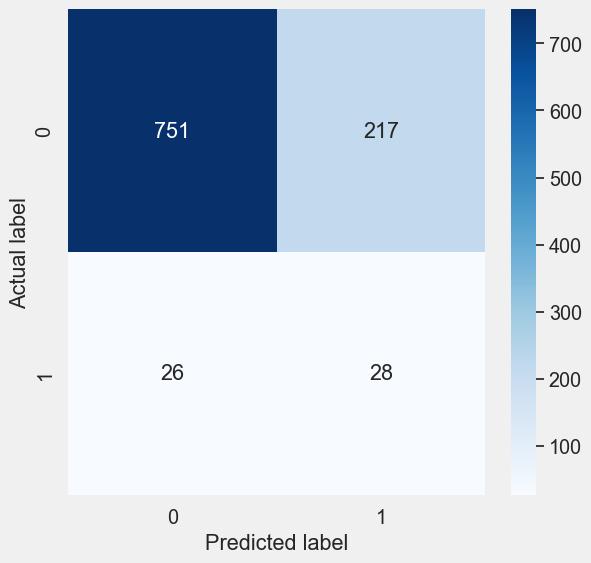

```
              precision    recall  f1-score   support

           0       0.97      0.78      0.86       968
           1       0.11      0.52      0.19        54

    accuracy                           0.76      1022
   macro avg       0.54      0.65      0.52      1022
weighted avg       0.92      0.76      0.83      1022

AUC_SVM: 0.647
Accuracy of The Model : 76.22309197651663
```

```python
plt.figure(figsize=(6, 6))
ax = plt.subplot()
cm = confusion_matrix(y_test,y_pred_svm)
sns.heatmap(cm, annot=True, ax = ax, fmt = 'g' ,cmap=plt.cm.Blues)
ax.set_xlabel('Predicted label')
ax.set_ylabel('Actual label')
plt.show()

print(classification_report(y_test,y_pred_svm))
print('AUC_SVM: {:.3f}'.format(roc_auc_score(y_test, y_pred_svm)))
print("Accuracy of The Model :",accuracy_score(y_test,y_pred_svm)*100)
```

### k-Nearest Neighbours

```python
from sklearn.neighbors import KNeighborsClassifier
knn_model=KNeighborsClassifier()
knn_model.fit(X_train_res,y_train_res) #create your model
```

```python
knn_model.fit(X_train_res,y_train_res) #create your model
```

```
KNeighborsClassifier()
```

```python
y_pred_knn=knn_model.predict(X_test) #create a prediction function
```

```python
ac_knn=accuracy_score(y_test,y_pred_knn)*100
```

```python
ac_knn
```

```
82.38747553816047
```

```python
auc_knn = roc_auc_score(y_test,y_pred_knn)*100
auc_knn
```

```
59.22865013774105
```

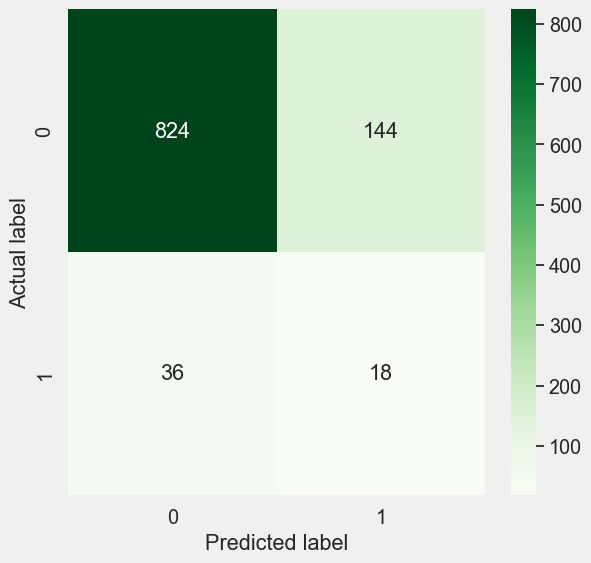

```
              precision    recall  f1-score   support

           0       0.96      0.85      0.90       968
           1       0.11      0.33      0.17        54

    accuracy                           0.82      1022
   macro avg       0.53      0.59      0.53      1022
weighted avg       0.91      0.82      0.86      1022

AUC_KNN: 0.592
Accuracy of The Model : 82.38747553816047
```

```python
plt.figure(figsize=(6, 6))
ax = plt.subplot()
cm = confusion_matrix(y_test, y_pred_knn)
sns.heatmap(cm, annot=True, ax = ax, fmt = 'g' ,cmap=plt.cm.Greens)
ax.set_xlabel('Predicted label')
ax.set_ylabel('Actual label')
plt.show()

print(classification_report(y_test,y_pred_knn))
print('AUC_KNN: {:.3f}'.format(roc_auc_score(y_test, y_pred_knn)))
print("Accuracy of The Model :",accuracy_score(y_test,y_pred_knn)*100)
```

### Random Forest

```python
from sklearn.ensemble import RandomForestClassifier
rf_model=RandomForestClassifier()
```

```python
rf_model.fit(X_train_res,y_train_res)
```

```
RandomForestClassifier()
```

```python
y_pred_rf=rf_model.predict(X_test)
```

```python
ac_rf=accuracy_score(y_test,y_pred_rf)*100
ac_rf
#print('AUC_rf: {:.3f}'.format(roc_auc_score(y_test, Y_pred)))
```

```
91.48727984344423
```

```python
auc_rf = roc_auc_score(y_test,y_pred_rf)*100
auc_rf
```

```
50.91827364554638
```

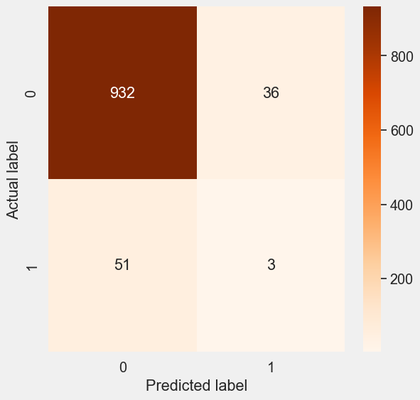

```
              precision    recall  f1-score   support

           0       0.95      0.96      0.96       968
           1       0.08      0.06      0.06        54

    accuracy                           0.91      1022
   macro avg       0.51      0.51      0.51      1022
weighted avg       0.90      0.91      0.91      1022

AUC_rf: 0.509
Accuracy of The Model : 91.48727984344423
```

```python
plt.figure(figsize=(6, 6))
ax = plt.subplot()
cm = confusion_matrix(y_test,y_pred_rf)
sns.heatmap(cm, annot=True, ax = ax, fmt = 'g' ,cmap=plt.cm.Oranges)
ax.set_xlabel('Predicted label')
ax.set_ylabel('Actual label')
plt.show()

print(classification_report(y_test,y_pred_rf))
print('AUC_rf: {:.3f}'.format(roc_auc_score(y_test, y_pred_rf)))
print("Accuracy of The Model :",accuracy_score(y_test, y_pred_rf)*100)
```

### Artificial Neural Network

```python
from tensorflow.keras.models import Sequential
from tensorflow.keras.layers import Dense
X_train_res.shape
```

```python
X_train_res.shape
```

```
(7786, 10)
```

**Build ANN**

```python
ann_model=Sequential()
ann_model.add(Dense(32,input_dim=X_train_res.shape[1],activation='relu'))
ann_model.add(Dense(16,activation='relu'))
ann_model.add(Dense(8,activation='relu'))
ann_model.add(Dense(4,activation='relu'))
ann_model.add(Dense(1,activation='sigmoid'))
```

```python
ann_model.compile(optimizer="adam",loss="binary_crossentropy",metrics=['accuracy'])
```

```python
ann_model.fit(X_train_res,y_train_res,batch_size=20,epochs = 20)
```

```
<keras.src.callbacks.History at 0x1260d8c78d0>
```

```python
y_pred_ann=ann_model.predict(X_test)
y_pred_ann=(y_pred_ann>0.5)
y_pred_ann=y_pred_ann.astype(int)
y_pred_ann[:4]
```

```
array([[0],
       [0],
       [0],
       [0]])
```

```python
ac_ann=accuracy_score(y_test, y_pred_ann)*100
ac_ann
```

```
83.75733855185909
```

```python
auc_ann = roc_auc_score(y_test,y_pred_ann)*100
auc_ann
```

```
56.45469850015304
```

```python
#print('AUC_ann: {:.3f}'.format(roc_auc_score(y_test, y_pred)))
```

```python
#print("Test set Accuracy: ", metrics.accuracy_score(y_test, y_pred))
```

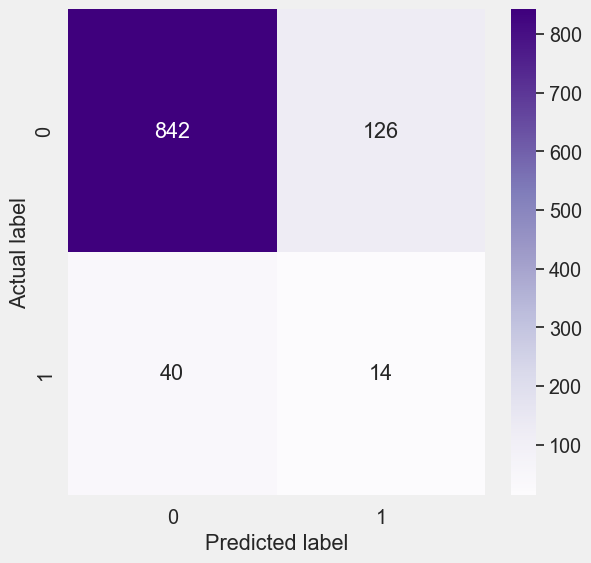

```
              precision    recall  f1-score   support

           0       0.95      0.87      0.91       968
           1       0.10      0.26      0.14        54

    accuracy                           0.84      1022
   macro avg       0.53      0.56      0.53      1022
weighted avg       0.91      0.84      0.87      1022

ANN_AUC: 0.565
Accuracy of The Model : 83.75733855185909
```

```python
plt.figure(figsize=(6, 6))
ax = plt.subplot()
cm = confusion_matrix(y_test,y_pred_ann)
sns.heatmap(cm, annot=True, ax = ax, fmt = 'g' ,cmap=plt.cm.Purples)
ax.set_xlabel('Predicted label')
ax.set_ylabel('Actual label')
plt.show()

print(classification_report(y_test,y_pred_ann))
print('ANN_AUC: {:.3f}'.format(roc_auc_score(y_test, y_pred_ann)))
print("Accuracy of The Model :",accuracy_score(y_test,y_pred_ann)*100)
```

```python
# plt.bar(['Logistic Regression','SVM','KNN','Random Forest','ANN'],[ac_lr,ac_svm,ac_knn,ac_rf,ac_ann])
# plt.xlabel("Algorithms")
# plt.ylabel("Accuracy")
# plt.show()
```

### XGBOOST

```python
!pip install xgboost
```

```python
from xgboost import XGBClassifier
xgb_model = XGBClassifier()
```

```python
xgb_model.fit(X_train_res, y_train_res)
```

```
XGBClassifier(base_score=None, booster=None, callbacks=None,
              colsample_bylevel=None, colsample_bynode=None,
              colsample_bytree=None, device=None, early_stopping_rounds=None,
              enable_categorical=False, eval_metric=None, feature_types=None,
              gamma=None, grow_policy=None, importance_type=None,
              interaction_constraints=None, learning_rate=None, max_bin=None,
              max_cat_threshold=None, max_cat_to_onehot=None,
              max_delta_step=None, max_depth=None, max_leaves=None,
              min_child_weight=None, missing=nan, monotone_constraints=None,
              multi_strategy=None, n_estimators=None, n_jobs=None,
              num_parallel_tree=None, random_state=None, ...)
```

```python
y_pred_xgb =xgb_model.predict(X_test) #Make predictions for values of y
```

```python
ac_xgb=accuracy_score(y_test, y_pred_xgb)*100 #confirm accuracy of predictions
ac_xgb
```

```
92.27005870841487
```

```python
auc_xgb = roc_auc_score(y_test,y_pred_xgb)*100
auc_xgb
```

```
53.08004285277013
```

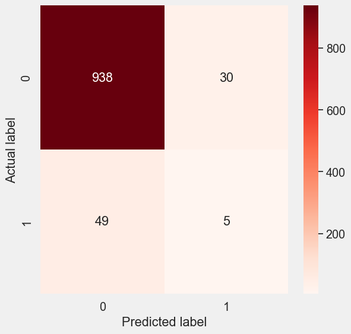

```
              precision    recall  f1-score   support

           0       0.95      0.97      0.96       968
           1       0.14      0.09      0.11        54

    accuracy                           0.92      1022
   macro avg       0.55      0.53      0.54      1022
weighted avg       0.91      0.92      0.91      1022

AUC_rf: 0.531
Accuracy of The Model : 92.27005870841487
```

```python
plt.figure(figsize=(6, 6))
ax = plt.subplot()
cm = confusion_matrix(y_test,y_pred_xgb)
sns.heatmap(cm, annot=True, ax = ax, fmt = 'g' ,cmap=plt.cm.Reds)
ax.set_xlabel('Predicted label')
ax.set_ylabel('Actual label')
plt.show()

print(classification_report(y_test,y_pred_xgb))
print('AUC_rf: {:.3f}'.format(roc_auc_score(y_test, y_pred_xgb)))
print("Accuracy of The Model :",accuracy_score(y_test, y_pred_xgb)*100)
```